# Final Project rev-7

## Introduction to Machine Learning Project

### Identify Fraud from Enron Email

Prepared by: Jeff Daniels  
November 30, 2017

## Introduction:

This project intends to use machine learning tools to identify persons of interest (poi) from a sample of Enron employees. Widespread fraud occured at Enron resulting in a federal investigation resuting in several poi who were indicted, reached a plea deal, or testified in exchange for immunity. The federal investigation also yielded a large public dataset containing detailed financial information and emails of employees.

A hand generated list of poi will be used to train a classifier that will identify poi based on their financial data. Machine learning is useful becuase we have a quantified dataset of financial information that is hopefully related to the likelihood of an employee commiting fraud. If a satisfactory algorithm is created it can be used to find other poi from the thousands of employees at Enron and not just in the approximately 145 samples in this dataset. A really good algorithm might also be useful in detecting fraud at other companies.

```python
#!/usr/bin/python2.7

"""
Setup Environment
"""

import pandas as pd
import numpy as np
import matplotlib.pyplot as plt

from tester import dump_classifier_and_data, test_classifier #
import tester

from helpers import construct_dataframe, create_new_features, dump_preperation, good_corr_features, \
                    good_corr_features_scores, k_best_features, load_dataset, outlier_table, prep_df, print_cv_scores, \
                    print_val_scores, process_nan, remove_all_zeros, remove_outliers, train_test_split

from sklearn.model_selection import GridSearchCV

from sklearn.naive_bayes import GaussianNB
from sklearn.tree import DecisionTreeClassifier
from sklearn.linear_model import LogisticRegression

from sklearn.pipeline import Pipeline
from sklearn.preprocessing import StandardScaler

from sklearn.decomposition import PCA

from sklearn.feature_selection import SelectKBest
```

## Exploratory Data Analysis

The dataset is loaded and converted into a dataframe for easier analysis and manipulation.

```python
data_dict = load_dataset()
enron = construct_dataframe(data_dict)
enron.info()
```

```
<class 'pandas.core.frame.DataFrame'>
Index: 146 entries, ALLEN PHILLIP K to YEAP SOON
Data columns (total 20 columns):
poi                          146 non-null int64
salary                       95 non-null float64
to_messages                  86 non-null float64
deferral_payments            39 non-null float64
total_payments               125 non-null float64
exercised_stock_options      102 non-null float64
bonus                        82 non-null float64
restricted_stock             110 non-null float64
shared_receipt_with_poi      86 non-null float64
restricted_stock_deferred    18 non-null float64
total_stock_value            126 non-null float64
expenses                     95 non-null float64
loan_advances                4 non-null float64
from_messages                86 non-null float64
other                        93 non-null float64
from_this_person_to_poi      86 non-null float64
director_fees                17 non-null float64
deferred_income              49 non-null float64
long_term_incentive          66 non-null float64
from_poi_to_this_person      86 non-null float64
dtypes: float64(19), int64(1)
memory usage: 24.0+ KB
```

```python
"""
Percentage of Dataset that is null
"""
print "Percentage of Dataset that is null"
enron.isnull().sum().sum()/float(enron.shape[0]*enron.shape[1])
```

```
Percentage of Dataset that is null
```

```
0.45308219178082193
```

```python
"""
Percentage of dataset who are poi
"""
print "Percentage of dataset who are poi"
enron['poi'].mean()
```

```
Percentage of dataset who are poi
```

```
0.12328767123287671
```

The dataset contains 146 people and 20 columns of features. There could potentially be 2920 data points, but 45% of the dataset contains null values. All but the poi feature contains null values. Because none of the classifiers accept null values, these data points will have to be addressed.

About 12% of the dataset are poi. This represents 18 people.

### Split the Dataset into Training and Test Sets

It is generally good practice to seperate the dataset into training and test sets. It is the first step in validating a classifier using a training and test data split. Other validation techniques are available, but working with a training set will reduce the "data snooping" bias. A stratified shuffle split will be used so that the same proportion of poi will occur in the training and test sets.

```python
train, test = train_test_split(enron)
df = train.copy()
```

### Remove Outliers

Let us start by identifying the outliers in the dataset. I have created a function that returns a table of employees whose features are more than 3 standard deviations from the mean of that feature.

```python
outlier_table(df)
```

|  | Outlier Feature | Value | poi |
| --- | --- | --- | --- |
| TOTAL | salary | 26704229 | 0 |
| KEAN STEVEN J | to_messages | 12754 | 0 |
| TOTAL | deferral_payments | 32083396 | 0 |
| TOTAL | total_payments | 309886585 | 0 |
| TOTAL | exercised_stock_options | 311764000 | 0 |
| TOTAL | bonus | 97343619 | 0 |
| TOTAL | restricted_stock | 130322299 | 0 |
| WHALLEY LAWRENCE G | shared_receipt_with_poi | 3920 | 0 |
| BHATNAGAR SANJAY | restricted_stock_deferred | 15456290 | 0 |
| TOTAL | total_stock_value | 434509511 | 0 |
| TOTAL | expenses | 5235198 | 0 |
| KAMINSKI WINCENTY J | from_messages | 14368 | 0 |
| TOTAL | other | 42667589 | 0 |
| KEAN STEVEN J | from_this_person_to_poi | 387 | 0 |
| DELAINEY DAVID W | from_this_person_to_poi | 609 | 1 |
| TOTAL | deferred_income | -27992891 | 0 |
| TOTAL | long_term_incentive | 48521928 | 0 |
| DIETRICH JANET R | from_poi_to_this_person | 305 | 0 |

This man/woman named 'TOTAL' is an outlier in 11 categories. We know from the course that this is a was probably a data entry error. Likely 'TOTAL' was calculated in a spreadsheet and the exported .csv file contained it. The best thing to do is simply discard it.

```python
if 'TOTAL' in df.index:
    df = df.drop(['TOTAL'])
outlier_table(df)['poi'].mean()
outlier_table(df)
```

|  | Outlier Feature | Value | poi |
| --- | --- | --- | --- |
| SKILLING JEFFREY K | salary | 1111258 | 1 |
| LAY KENNETH L | salary | 1072321 | 1 |
| KEAN STEVEN J | to_messages | 12754 | 0 |
| LAY KENNETH L | total_payments | 103559793 | 1 |
| HIRKO JOSEPH | exercised_stock_options | 30766064 | 1 |
| LAY KENNETH L | exercised_stock_options | 34348384 | 1 |
| SKILLING JEFFREY K | bonus | 5600000 | 1 |
| LAY KENNETH L | bonus | 7000000 | 1 |
| PAI LOU L | restricted_stock | 8453763 | 0 |
| LAY KENNETH L | restricted_stock | 14761694 | 1 |
| WHALLEY LAWRENCE G | shared_receipt_with_poi | 3920 | 0 |
| BHATNAGAR SANJAY | restricted_stock_deferred | 15456290 | 0 |
| HIRKO JOSEPH | total_stock_value | 30766064 | 1 |
| LAY KENNETH L | total_stock_value | 49110078 | 1 |
| URQUHART JOHN A | expenses | 228656 | 0 |
| KAMINSKI WINCENTY J | from_messages | 14368 | 0 |
| LAY KENNETH L | other | 10359729 | 1 |
| KEAN STEVEN J | from_this_person_to_poi | 387 | 0 |
| DELAINEY DAVID W | from_this_person_to_poi | 609 | 1 |
| RICE KENNETH D | deferred_income | -3504386 | 1 |
| MARTIN AMANDA K | long_term_incentive | 5145434 | 0 |
| LAY KENNETH L | long_term_incentive | 3600000 | 1 |
| DIETRICH JANET R | from_poi_to_this_person | 305 | 0 |

Removing TOTAL seems to give us a better set of outliers. In fact, this group of outliers is 61% poi. This is probably a case when outliers represent something exceptional, such as fraud, that we are trying to identify. Therefore, I will keep these samples in the dataset.

So for now, the only outlier we ignore is TOTAL. The problem with this removing this outlier is supposing what would happen if TOTAL was in the test set. Then this outlier wouldn't have been removed and a bad classification may have occured. Are there other outliers that are in the test set that won't be considered?

```python
df = remove_outliers(df)
```

### Create new features

New features were created that illustrated the ratio of emails from, sent to, or shared receipt with a poi to the total number of emails received or sent. Hopefully this would represent some sort of measure of collusion between parties to commit fraud.

```python
df = create_new_features(df)
```

### Process the NaN Values

Something must be done about the null values in the dataset. There already exist zero values in the dataset so null values are somehow different. I will assume that these values are null because of lack of information. The options are to set all of them to zero, or to set them to a median value for that feature. I decided to go with set them all to zero.

```python
df = process_nan(df)
```

### Remove all Zeros

The tester code has an option that is exercised to remove any rows where all the values are zero. It seems like a good idea to carry out this practice in our EDA.

```python
df = remove_all_zeros(df)
```

### Look at the clean data

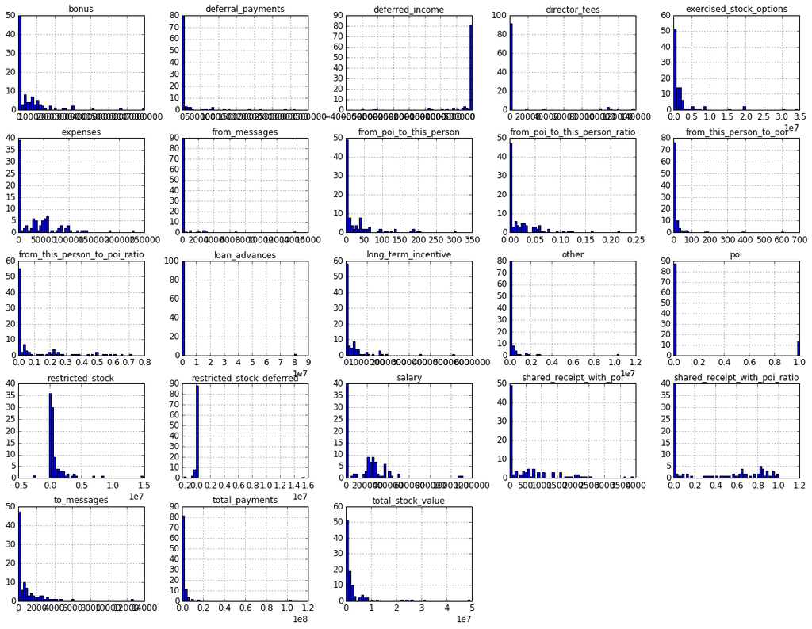

```python
"""
Histogram Plots of the data
"""

plt.rcParams['axes.labelsize'] = 14
plt.rcParams['xtick.labelsize'] = 12
plt.rcParams['ytick.labelsize'] = 12

df.hist(bins=50, figsize=(20,15), log = False)
plt.show()
```

### Validate three classifiers

Validation measures the ability of a classifier to generalize data. Typically, the classifier is trained on one set of data and then the performance of that classifier is evaluated on a seperate test set of data. Validation should prevent a classifier from overfitting the data. A model can be created from the training data that accurately classifies all the samples. If this model is then applied to another dataset and poorly classifies that data, then overfitting has probably occurred. The purpose of validation is to help a classifier generalize not just training data well, but all data. The goal is for the performance of a classifier on the training set to be similar to the performance on the test set.

A Gaussian Naive Bayes, Decision Tree, and logistic regression classifiers were considered. All were trained on the training set and validated by running the classifier with the test set data. The two performance metrics I have chosen to evaluate the classifiers are precision and recall. Precision is the probability that a person predicted to be a poi is actually a poi. It is the ratio of true positives to the sum of true positives and false positives:

\begin{equation*} precision = \frac{tp}{tp+fp} \end{equation*}

Recall is the ratio of true positives to the sum of true positives and false negatives. It is the fraction of poi in our dataset whom the classifier predicted were poi:

\begin{equation*} recall = \frac{tp}{tp+fn} \end{equation*}

Because poi made up about 12% of the dataset, it would be easy to create a classifier that identified all samples as non-poi and achieve an 88% accuracy. Then the algorithm would find no poi but have high precision. If you want to identify all poi, then a high recall rate is desireable but a lazily constructed algorithm would just classify all samples as poi. Practically, it would be expensive to investigate everyone. Finding a balance between precision and recall is a classic classifier conundrum. An easy way to consider both precision and recall in validating a classifier is to use the harmonic mean of the two scores which is known as the f1 score:

\begin{equation*} f1 = \frac{2tp}{2tp+fp+fn} \end{equation*}

```python
"""
Train three classifiers on the training set
Test them on the Test set
Display a dataframe with evaluation scores
"""

"""
Prepare the training and test sets for classifiers
"""
features_train, labels_train = prep_df(train)
features_test, labels_test = prep_df(test)


"""
Summarize Classifiers before tuning
"""

val_before_tuning = \
pd.DataFrame(columns = ["accuracy", "precision", "recall", "f1"])

# GaussianNB classifier
clf = GaussianNB()
val_before_tuning = \
val_before_tuning.append(print_val_scores(clf, features_train, features_test,
                                                 labels_train, labels_test,
                                                 print_out = False))

# Decision Tree Classifier
clf = DecisionTreeClassifier(random_state = 42)
val_before_tuning = \
val_before_tuning.append(print_val_scores(clf, features_train, features_test,
                                                 labels_train, labels_test,
                                                 print_out = False))

# Logistic Regression Classifier
clf = LogisticRegression()
val_before_tuning = \
val_before_tuning.append(print_val_scores(clf, features_train, features_test,
                                                 labels_train, labels_test,
                                                 print_out = False))

val_before_tuning.index = ['Gaussian Naive Bayes', 'Decision Tree', 'Logistic Regression']

print "Validation Scores before Tuning and Feature Selection"
val_before_tuning
```

```
Validation Scores before Tuning and Feature Selection
```

|  | accuracy | precision | recall | f1 |
| --- | --- | --- | --- | --- |
| Gaussian Naive Bayes | 0.772727 | 0.000000 | 0.0 | 0.000000 |
| Decision Tree | 0.795455 | 0.166667 | 0.2 | 0.181818 |
| Logistic Regression | 0.727273 | 0.000000 | 0.0 | 0.000000 |

Validation using a training and test data split have given us some poor results. The Naive Bayes and Logistic Regression classifiers both had precision and recall equal to zero. This is partly because the classifiers may be inappropriate or could use some tuning. It may also be because the validation method isn't appropriate. Ultimately the classifier I choose will be validated using the test_classifier function in tester. test_classifier uses a cross validation technique where the entire dataset is divided into training and test sets for multiple iterations and returns a mean of the validation scores for all iterations. test_classifier uses StratifiedShuffleSplit to split the dataset into a training set of 90% of the samples and a test set of 10%. There are 1000 iterations of this split with a different training and test sets each time. This cross validation strategy is useful for smaller datasets like ours since it reuses the data several times.

For comparison, let us see how cross validation scores from test_classifier compare to our simple validation.

```python
"""
test_classifier performance before tuning and feature selection
"""

my_dataset, features_list = dump_preperation(enron, list(features_train.columns))

test_classifier(GaussianNB(), my_dataset, features_list)
test_classifier(DecisionTreeClassifier(random_state=42), my_dataset, features_list)
test_classifier(LogisticRegression(), my_dataset, features_list)
```

```
GaussianNB(priors=None)
	Accuracy: 0.74713	Precision: 0.23578	Recall: 0.40000	F1: 0.29668	F2: 0.35109
	Total predictions: 15000	True positives:  800	False positives: 2593	False negatives: 1200	True negatives: 10407

DecisionTreeClassifier(class_weight=None, criterion='gini', max_depth=None,
            max_features=None, max_leaf_nodes=None,
            min_impurity_decrease=0.0, min_impurity_split=None,
            min_samples_leaf=1, min_samples_split=2,
            min_weight_fraction_leaf=0.0, presort=False, random_state=42,
            splitter='best')
	Accuracy: 0.81413	Precision: 0.29020	Recall: 0.27250	F1: 0.28107	F2: 0.27587
	Total predictions: 15000	True positives:  545	False positives: 1333	False negatives: 1455	True negatives: 11667

LogisticRegression(C=1.0, class_weight=None, dual=False, fit_intercept=True,
          intercept_scaling=1, max_iter=100, multi_class='ovr', n_jobs=1,
          penalty='l2', random_state=None, solver='liblinear', tol=0.0001,
          verbose=0, warm_start=False)
	Accuracy: 0.78233	Precision: 0.17812	Recall: 0.17500	F1: 0.17654	F2: 0.17561
	Total predictions: 15000	True positives:  350	False positives: 1615	False negatives: 1650	True negatives: 11385
```

```python
test_classifier_before_tuning = \
pd.DataFrame([[0.747, 0.236, 0.400, 0.297, 0.351],
            [0.814, 0.290, 0.273, 0.281, 0.276],
            [0.782, 0.178, 0.175, 0.177, 0.177]],
             columns = ["accuracy", "precision", "recall", "f1", "f2"],
            index = ['Gaussian Naive Bayes', 'Decision Tree', 'Logistic Regression'])

print "test_classifier Scores before Tuning and Feature Selection"
test_classifier_before_tuning
```

```
test_classifier Scores before Tuning and Feature Selection
```

|  | accuracy | precision | recall | f1 | f2 |
| --- | --- | --- | --- | --- | --- |
| Gaussian Naive Bayes | 0.747 | 0.236 | 0.400 | 0.297 | 0.351 |
| Decision Tree | 0.814 | 0.290 | 0.273 | 0.281 | 0.276 |
| Logistic Regression | 0.782 | 0.178 | 0.175 | 0.177 | 0.177 |

Indeed, the cross validation is a little more forgiving and probably more accurate than validating with just one train/test split. Still, none of the classifiers meet the rubric requirement of precision and accuracy greater than 0.3. The next section will try to improve classifier performance through feature selection and hyperparameter tuning.

### Tuning Hyperparameters and Performance Metric

Tuning the classifiers means adjusting the hyperparameters to optimize classifier performance. Hyperparameters are parameters that are set before training the classifier on the data. The data can change, the classifier will change its coefficients, but the hyperparameters will stay the same. The classifier performance will be judged on f1 score. By maximizing the f1 score, the precision and recall scores will both hopefully be indidually maximized as well. Also tuning with more than one scoring criteria is inconvenient.

As explained before, cross validation is a good way of reusing data to get what is hopefully a more accurate performance score. For tuning the classifiers, cross validation will be used to evaluate the performance of the classifier hyperparameters. Generally a 3 fold cross validation will be used for tuning but only on the training data so that the classifier can be validated again on the test data.

### Tune the Gaussian Classifier

There are not many tuning parameters in the Gaussian Naive Bayes classifier. I'll do my best to pick out good features. good_corr_features ranks the features that highly correlate with the 'poi' label then creates subsets of the features, returning the subsets features that performed best. The first subset contains only the highest correlating feature, the second has the two highest correlating features, and so on until the number of subsets equals the number of features.

```python
print 'Correlation of Features with poi'
df.corr()['poi'].sort_values(ascending = False)
```

```
Correlation of Features with poi
```

```
poi                              1.000000
exercised_stock_options          0.494995
total_stock_value                0.493908
salary                           0.447438
bonus                            0.437867
long_term_incentive              0.374413
restricted_stock                 0.370327
from_this_person_to_poi_ratio    0.342256
total_payments                   0.282558
loan_advances                    0.259998
shared_receipt_with_poi          0.252883
other                            0.249747
shared_receipt_with_poi_ratio    0.230686
from_poi_to_this_person          0.199290
expenses                         0.197379
from_this_person_to_poi          0.188880
to_messages                      0.125637
from_poi_to_this_person_ratio    0.105680
from_messages                   -0.027681
restricted_stock_deferred       -0.027782
director_fees                   -0.112199
deferral_payments               -0.117645
deferred_income                 -0.312149
Name: poi, dtype: float64
```

```python
"""
Run good_corr_features and display the list of features selected
"""
list(good_corr_features(features_train, labels_train, clf = GaussianNB()).columns)
```

```
['exercised_stock_options']
```

So it appears that my feature selection function good_corr_features returned a list containing only one feature. It will be interesting to see if this was an effective strategy.

```python
"""
Automated Feature Selection for Gaussian NB
"""

print "Before Feature Selection"
print_cv_scores(GaussianNB(), features_train, labels_train)

"""
List the features that correspond to the highest f1 score
"""
good_gnb_features_train = good_corr_features(features_train, labels_train, clf = GaussianNB())

print ""
print 'Good Correlated Features'
print list(good_gnb_features_train.columns)
print ""
print "After Feature Selection"
gnb_fs_score = print_cv_scores(GaussianNB(), good_gnb_features_train, labels_train)
gnb_fs_score.index = ['Gaussian Naive Bayes w/ Feature Selection']

print ""
print "Validation on Test Set"
good_gnb_features_test = features_test[list(good_gnb_features_train.columns)]
_ = print_val_scores(GaussianNB(), good_gnb_features_train, good_gnb_features_test, labels_train, labels_test)
```

```
Before Feature Selection
Mean Cross Validation Scores
accuracy 0.699049316696
precision 0.272222222222
recall 0.466666666667
f1 0.299783549784

Good Correlated Features
['exercised_stock_options']

After Feature Selection
Mean Cross Validation Scores
accuracy 0.879976232917
precision 0.666666666667
recall 0.4
f1 0.444444444444

Validation on Test Set
Validation Scores
accuracy 0.840909090909
precision 0.0
recall 0.0
f1 0.0
```

The validation scores haven't changed. The f1 score is 0.0. This may be an example of overfitting. The set of features chosen based on the training set didn't work well on the test set. Feature selection can be an art of finding the happy medium between too few features and too many features which can both cause overfitting. Let us examine the mean f1 scores found from the cross validation versus the number of features.

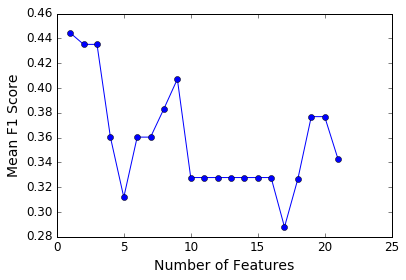

```python
"""
Plot Mean F1 Score from cross validation vs. Number of features
"""

results_df = good_corr_features_scores(features_train, labels_train, GaussianNB())
fig = plt.figure()
plt.plot(results_df, marker = 'o')
plt.xlabel('Number of Features')
plt.ylabel('Mean F1 Score')
plt.show()
```

A feature list with only one feature does appear to have the best performance but I would like to ignore feature lists that have too little and too many features. There is a local maxima in performace where the number of features is 9 which looks promising. Lets retrain and validate using this new set of features.

```python
"""
Manual Feature Selection for GaussianNB
Select the top 9 correlated features
"""
num_gnb_features = 9


print "Before Feature Selection"
print_cv_scores(GaussianNB(), features_train, labels_train)

"""
List the features selected
"""
top_corr = list(abs(features_train.corrwith(labels_train)).sort_values(
            ascending = False).index)
good_gnb_features_train = features_train[top_corr[0:num_gnb_features]]
good_gnb_features_test = features_test[list(good_gnb_features_train.columns)]

print ""
print 'Features selected with good correlations to POI'
print list(good_gnb_features_train.columns)
print ""
print "After Feature Selection"
gnb_fs_score = print_cv_scores(GaussianNB(), good_gnb_features_train, labels_train)
gnb_fs_score.index = ['Gaussian Naive Bayes w/ Feature Selection']

print ""
print "Validation on Test Set"
_ = print_val_scores(GaussianNB(), good_gnb_features_train, good_gnb_features_test, labels_train, labels_test)
```

```
Before Feature Selection
Mean Cross Validation Scores
accuracy 0.699049316696
precision 0.272222222222
recall 0.466666666667
f1 0.299783549784

Features selected with good correlations to POI
['exercised_stock_options', 'total_stock_value', 'salary', 'bonus', 'long_term_incentive', 'restricted_stock', 'from_this_person_to_poi_ratio', 'deferred_income', 'total_payments']

After Feature Selection
Mean Cross Validation Scores
accuracy 0.849376114082
precision 0.527777777778
recall 0.383333333333
f1 0.407142857143

Validation on Test Set
Validation Scores
accuracy 0.840909090909
precision 0.25
recall 0.2
f1 0.222222222222
```

Manually selecting the top 9 features with the highest correlation to poi decreased the cross validation scores but increased the validation scores on the test set. This new set of features includes one new feature 'from_this_person_to_poi_ratio' which compares the number of emails from this person to a poi to total emails sent by this person. The new feature ranks 7/9 for correlation with poi among the features selected. The features selected and their correlations with poi are below:

```python
abs(features_train.corrwith(labels_train)).sort_values(
            ascending = False)[0:num_gnb_features]
```

```
exercised_stock_options          0.494995
total_stock_value                0.493908
salary                           0.447438
bonus                            0.437867
long_term_incentive              0.374413
restricted_stock                 0.370327
from_this_person_to_poi_ratio    0.342256
deferred_income                  0.312149
total_payments                   0.282558
dtype: float64
```

Now that I have chosen some features, let us try implementing the Naive Bayes classifier with or without principle component analysis. This will be done by implementing a Pipeline along with GridSearchCV which will test all the combinations of hyperparameters that I provide. Along with determining whether PCA improves performance, the PCA hyperparameter n_components will be tuned so that hopefully the best version of PCA will be compared to not using PCA.

```python
"""
Tune the Naive Bayes Classifier
"""
cv_folds = 3

pipe = Pipeline([
    ('reduce_dim', PCA()),
    ('classify', GaussianNB())
])

N_FEATURES_OPTIONS = [2, 3, 4,5, 6, 7, 8]

param_grid = [{'reduce_dim': [PCA(random_state=42)],
                'reduce_dim__n_components': N_FEATURES_OPTIONS},
              {'reduce_dim': [None]}
             ]

estimator = GridSearchCV(pipe, param_grid = param_grid, cv = cv_folds, scoring = 'f1')
estimator.fit(good_gnb_features_train, labels_train)

clf_gnb = estimator.best_estimator_

print "Before Tuning"
print_cv_scores(GaussianNB(), good_gnb_features_train, labels_train, cv = cv_folds)
print ""
print "After Tuning"
dt_tune_score = print_cv_scores(clf_gnb, good_gnb_features_train, labels_train, cv = cv_folds)
dt_tune_score.index = ['Gaussian Naive Bayes w/ Tuning']
print""
_ = print_val_scores(clf_gnb, good_gnb_features_train, good_gnb_features_test,
                                                 labels_train, labels_test)

print ""
clf_gnb.named_steps
print ""

my_dataset, features_list = dump_preperation(enron, list(good_gnb_features_train.columns))
test_classifier(clf_gnb, my_dataset, features_list)
```

```
Before Tuning
Mean Cross Validation Scores
accuracy 0.849376114082
precision 0.527777777778
recall 0.383333333333
f1 0.407142857143

After Tuning
Mean Cross Validation Scores
accuracy 0.82917409388
precision 0.527777777778
recall 0.466666666667
f1 0.434920634921

Validation Scores
accuracy 0.840909090909
precision 0.25
recall 0.2
f1 0.222222222222


Pipeline(memory=None,
     steps=[('reduce_dim', PCA(copy=True, iterated_power='auto', n_components=6, random_state=42,
  svd_solver='auto', tol=0.0, whiten=False)), ('classify', GaussianNB(priors=None))])
	Accuracy: 0.85653	Precision: 0.45202	Recall: 0.35800	F1: 0.39955	F2: 0.37354
	Total predictions: 15000	True positives:  716	False positives:  868	False negatives: 1284	True negatives: 12132
```

GridSearchCV has shown us that using PCA with n_components = 6 improves recall. Running this new classifier with the 9 features selected also yields better test_classifier performance. Manual feature selection and PCA improved the performance of the Gaussian Naive Bayes classifier to where it now meets the requirements for submission.

### Tune the Decision Tree Classifier

The Decision Tree Classifier has the attribute feature*importances* which can be used in conjunction with SelectKBest to select the features. SelectKBest is feature selection method that selects the best features based on univariate statistical tests. Using GridSearchCV, different numbers of features can be tested in the SelectKBest preprocessing step. The decision tree classifier also has many more hyperparameters than the Gaussian Naive Bayes classifier so it is well suited to GridSearchCV using parameter grids with larger dimensions. The classifier will be evaluated with or without a scaler and using either SelectKBest or PCA to reduce dimensionality. Hyperparameters will be tuned as well.

```python
"""
Tune the Decision Tree Classifier
"""
cv_folds = 3

pipe = Pipeline([
    ('scaler', StandardScaler()),
    ('reduce_dim', SelectKBest()),
    ('classify', DecisionTreeClassifier(random_state = 42))
])

N_FEATURES_OPTIONS = [2, 4, 8, 16, 20]
MAX_DEPTH_OPTIONS = [2, 4, 6, 8]
MIN_SAMPLES_OPTIONS = [1,2, 4, 8]
CRITERION_OPTIONS = ['entropy', 'gini']

param_grid = [{'reduce_dim': [PCA(random_state=42)],
                'reduce_dim__n_components': N_FEATURES_OPTIONS,
                'classify__criterion': CRITERION_OPTIONS,
                'classify__max_depth': MAX_DEPTH_OPTIONS,
              'classify__min_samples_leaf': MIN_SAMPLES_OPTIONS},
              {'scaler': [None],
                'reduce_dim': [PCA(random_state=42)],
                'reduce_dim__n_components': N_FEATURES_OPTIONS,
                'classify__criterion': CRITERION_OPTIONS,
                'classify__max_depth': MAX_DEPTH_OPTIONS,
              'classify__min_samples_leaf': MIN_SAMPLES_OPTIONS},
              {'reduce_dim': [SelectKBest()],
                'reduce_dim__k': N_FEATURES_OPTIONS,
                'classify__criterion': CRITERION_OPTIONS,
                'classify__max_depth': MAX_DEPTH_OPTIONS,
              'classify__min_samples_leaf': MIN_SAMPLES_OPTIONS},
              {'scaler': [None],
                  'reduce_dim': [SelectKBest()],
                'reduce_dim__k': N_FEATURES_OPTIONS,
                'classify__criterion': CRITERION_OPTIONS,
                'classify__max_depth': MAX_DEPTH_OPTIONS,
              'classify__min_samples_leaf': MIN_SAMPLES_OPTIONS}
             ]

estimator = GridSearchCV(pipe, param_grid = param_grid, cv = cv_folds, scoring = 'f1')
estimator.fit(features_train, labels_train)

clf_dt = estimator.best_estimator_

print "Before Tuning"
print_cv_scores(DecisionTreeClassifier(random_state=42), features_train, labels_train, cv = cv_folds)
print ""
print "After Tuning"
dt_tune_score = print_cv_scores(clf_dt, features_train, labels_train, cv = cv_folds)
dt_tune_score.index = ['Decision Tree w/ Tuning']
print""
_ = print_val_scores(clf_dt, features_train, features_test,
                                                 labels_train, labels_test)

clf_dt.named_steps
```

```
Before Tuning
Mean Cross Validation Scores
accuracy 0.839572192513
precision 0.533333333333
recall 0.316666666667
f1 0.333333333333

After Tuning
Mean Cross Validation Scores
accuracy 0.889483065954
precision 0.633333333333
recall 0.533333333333
f1 0.564814814815

Validation Scores
accuracy 0.840909090909
precision 0.25
recall 0.2
f1 0.222222222222
```

```
{'classify': DecisionTreeClassifier(class_weight=None, criterion='gini', max_depth=6,
             max_features=None, max_leaf_nodes=None,
             min_impurity_decrease=0.0, min_impurity_split=None,
             min_samples_leaf=1, min_samples_split=2,
             min_weight_fraction_leaf=0.0, presort=False, random_state=42,
             splitter='best'),
 'reduce_dim': SelectKBest(k=8, score_func=<function f_classif at 0x7e8b1b2432a8>),
 'scaler': StandardScaler(copy=True, with_mean=True, with_std=True)}
```

It seems that decision tree classifier works best with StandardScaler and SelectKBest with 8 features. The validation scores improved slightly so it does not seem like overfiting has occured. The new feature 'from_this_person_to_poi_ratio' is included among the features chosen. The new feature has less than half the importance of some of the features chosen. The new feature ranks 7/8 in importance for the features selected. The features selected are listed below with their scores.

```python
k_best_features(clf_dt, features_train)
```

```
[(31.804845880114033, 'exercised_stock_options'),
 (31.620178218715953, 'total_stock_value'),
 (24.530714329629465, 'salary'),
 (23.246288774158632, 'bonus'),
 (15.978062688236019, 'long_term_incentive'),
 (15.576085413176642, 'restricted_stock'),
 (13.002739226503381, 'from_this_person_to_poi_ratio'),
 (10.579685358065349, 'deferred_income')]
```

```python
"""
test_classifier on the tuned Decision Tree Classifier
kbest features selected
"""

my_dataset, features_list = dump_preperation(enron, list(features_train.columns))
test_classifier(clf_dt, my_dataset, features_list)
```

```
Pipeline(memory=None,
     steps=[('scaler', StandardScaler(copy=True, with_mean=True, with_std=True)), ('reduce_dim', SelectKBest(k=8, score_func=<function f_classif at 0x7e8b1b2432a8>)), ('classify', DecisionTreeClassifier(class_weight=None, criterion='gini', max_depth=6,
            max_features=None, max_leaf_nodes=None,
...        min_weight_fraction_leaf=0.0, presort=False, random_state=42,
            splitter='best'))])
	Accuracy: 0.80860	Precision: 0.27139	Recall: 0.25850	F1: 0.26479	F2: 0.26098
	Total predictions: 15000	True positives:  517	False positives: 1388	False negatives: 1483	True negatives: 11612
```

Running our tuned Decision Tree Classifier through the test_classifier function yields performance that does not meet the rubric requirements. How could this be? Why are cross validation scores from the training set so different from the validation scores on the test set and cross validation scores on the entire dataset? One reason is that my cross validation uses only 3 folds whereas test classifier uses 1000 folds. Three folds seems a reasonable number to use when tuning the classifier because it takes less time. However, using a 70/30 training/test set for validation may not be the best method for this particular dataset.